# **LearningBox**

Maintained by Suprapto van Plaosan (https://www.facebook.com/LearningBox-2022902234682612/?ref=page_internal)

# Topik

- Belajar Klasterisasi KMeans Menggunakan Python
- Belajar Principal Component Analysis (PCA) Menggunakan Python
- Affinity Propagation (AP) Clustering Menggunakan Python

# Belajar Klasterisasi KMeans Menggunakan Python

Suprapto van Plaosan

[figure not shown]

Woodstack 8, originally uploaded by stevenjbaker (creative-common)

Klasterisasi data menggunakan KMeans merupakan algoritma yang sangat populer karena kemudahannya. Data akan dikelompokkan berdasarkan kedekatan masing-masing titik data pada titik beratnya. Secara umum, data yang jaraknya dekat biasanya mempunyai kesamaan yang lebih besar daripada data yang jaraknya jauh. Jarak antar data biasanya diukur menggunakan *Eucledian Distance*.

Klasterisasi data KMeans di Python dapat dilakukan dengan mengimpor pustaka KMeans dari **scikitlearn cluster**

## Breast Cancer Wisconsin (Diagnostic) Data Set

Diagnosis dan deteksi dini kanker payudara dengan mendiagnosis massa payudara dari Aspirasi Jarum Halus (FNA) telah dibuat yang memungkinkan diagnosis FNA payudara bahkan oleh pengguna yang tidak terlatih. Sistem ini digunakan di Rumah Sakit University of Wisconsin. Antarmuka grafis dikembangkan untuk menghitung fitur wilayah kecil dari FNA didigitalkan, menghasilkan 640 × 400, 8-bit-per-pixel gambar *grayscale*. Program analisis gambar, program Xcyt digunakan untuk *fitting* kurva untuk menentukan batas-batas inti. Sebagian dari gambar yang diproses ditunjukkan pada Gambar 1. Sepuluh fitur dihitung untuk masing-masing inti: luas, jari-jari, keliling, simetri, jumlah dan ukuran cekung, dimensi fraktal (batas), kekompakan, kehalusan dan tekstur. Data diagnosis berisi simbol **B** dan **M** yang mewakili *Benign*/Sehat dan *Malignant*/Sakit.

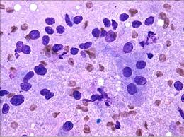

Gambar 1: Gambar FNA yang diperbesar dari sel kanker payudara ganas

```python
from sklearn.cluster import KMeans
```

```python
import pandas as pd
```

```python
names=['ID','Diagnosis','radius','texture','perimeter','area','smoothness','compactness','concavity','concave','symmetry','fractal','sradius','stexture','sperimeter','sarea','ssmoothness','scompactness','sconcavity','sconcave','ssymmetry','sfractal','wradius','wtexture','wperimeter','warea','wsmoothness','wcompactness','wconcavity','wconcave','wsymmetry','wfractal']
```

```python
df1=pd.read_csv('https://archive.ics.uci.edu/ml/machine-learning-databases/breast-cancer-wisconsin/wdbc.data',names=names)
```

```python
df=df1.iloc[:,1:12]
```

```python
df.head()
```

|  | Diagnosis | radius | texture | perimeter | area | smoothness | compactness | concavity | concave | symmetry | fractal |
| --- | --- | --- | --- | --- | --- | --- | --- | --- | --- | --- | --- |
| 0 | M | 17.99 | 10.38 | 122.80 | 1001.0 | 0.11840 | 0.27760 | 0.3001 | 0.14710 | 0.2419 | 0.07871 |
| 1 | M | 20.57 | 17.77 | 132.90 | 1326.0 | 0.08474 | 0.07864 | 0.0869 | 0.07017 | 0.1812 | 0.05667 |
| 2 | M | 19.69 | 21.25 | 130.00 | 1203.0 | 0.10960 | 0.15990 | 0.1974 | 0.12790 | 0.2069 | 0.05999 |
| 3 | M | 11.42 | 20.38 | 77.58 | 386.1 | 0.14250 | 0.28390 | 0.2414 | 0.10520 | 0.2597 | 0.09744 |
| 4 | M | 20.29 | 14.34 | 135.10 | 1297.0 | 0.10030 | 0.13280 | 0.1980 | 0.10430 | 0.1809 | 0.05883 |

```python
df.to_csv('wdbc10.csv')
```

```python
df.describe()
```

|  | radius | texture | perimeter | area | smoothness | compactness | concavity | concave | symmetry | fractal |
| --- | --- | --- | --- | --- | --- | --- | --- | --- | --- | --- |
| count | 569.000000 | 569.000000 | 569.000000 | 569.000000 | 569.000000 | 569.000000 | 569.000000 | 569.000000 | 569.000000 | 569.000000 |
| mean | 14.127292 | 19.289649 | 91.969033 | 654.889104 | 0.096360 | 0.104341 | 0.088799 | 0.048919 | 0.181162 | 0.062798 |
| std | 3.524049 | 4.301036 | 24.298981 | 351.914129 | 0.014064 | 0.052813 | 0.079720 | 0.038803 | 0.027414 | 0.007060 |
| min | 6.981000 | 9.710000 | 43.790000 | 143.500000 | 0.052630 | 0.019380 | 0.000000 | 0.000000 | 0.106000 | 0.049960 |
| 25% | 11.700000 | 16.170000 | 75.170000 | 420.300000 | 0.086370 | 0.064920 | 0.029560 | 0.020310 | 0.161900 | 0.057700 |
| 50% | 13.370000 | 18.840000 | 86.240000 | 551.100000 | 0.095870 | 0.092630 | 0.061540 | 0.033500 | 0.179200 | 0.061540 |
| 75% | 15.780000 | 21.800000 | 104.100000 | 782.700000 | 0.105300 | 0.130400 | 0.130700 | 0.074000 | 0.195700 | 0.066120 |
| max | 28.110000 | 39.280000 | 188.500000 | 2501.000000 | 0.163400 | 0.345400 | 0.426800 | 0.201200 | 0.304000 | 0.097440 |

```python
import seaborn as sb
```

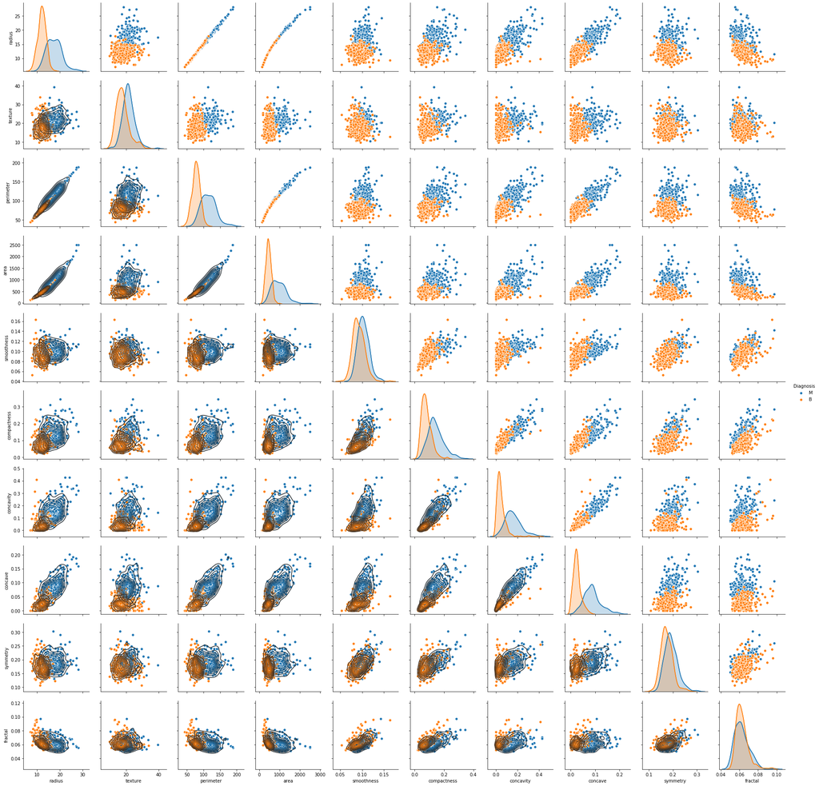

```python
g=sb.pairplot(df, hue='Diagnosis')
g.map_lower(sb.kdeplot)
g.map_diag(sb.kdeplot)
```

## **Koefisien korelasi**

dari Wikipedia, ensiklopedia gratis

Koefisien korelasi adalah ukuran numerik dari beberapa jenis korelasi , yang berarti hubungan statistik antara dua variabel . [1] Variabel dapat berupa dua kolom dari kumpulan data pengamatan tertentu, sering disebut sampel , atau dua komponen variabel acak multivariat dengan distribusi yang diketahui .

Ada beberapa jenis koefisien korelasi, masing-masing dengan definisi dan jangkauan kegunaan dan karakteristik masing-masing. Mereka semua mengasumsikan nilai dalam kisaran dari −1 hingga +1, di mana ± 1 menunjukkan kesepakatan terkuat dan 0 ketidaksetujuan sekuat mungkin. [2] Sebagai alat analisis, koefisien korelasi menyajikan masalah-masalah tertentu, termasuk kecenderungan beberapa jenis untuk terdistorsi oleh pencilan dan kemungkinan salah digunakan untuk menyimpulkan hubungan sebab akibat antara variabel.

```python
df.corr()
```

|  | radius | texture | perimeter | area | smoothness | compactness | concavity | concave | symmetry | fractal |
| --- | --- | --- | --- | --- | --- | --- | --- | --- | --- | --- |
| radius | 1.000000 | 0.323782 | 0.997855 | 0.987357 | 0.170581 | 0.506124 | 0.676764 | 0.822529 | 0.147741 | -0.311631 |
| texture | 0.323782 | 1.000000 | 0.329533 | 0.321086 | -0.023389 | 0.236702 | 0.302418 | 0.293464 | 0.071401 | -0.076437 |
| perimeter | 0.997855 | 0.329533 | 1.000000 | 0.986507 | 0.207278 | 0.556936 | 0.716136 | 0.850977 | 0.183027 | -0.261477 |
| area | 0.987357 | 0.321086 | 0.986507 | 1.000000 | 0.177028 | 0.498502 | 0.685983 | 0.823269 | 0.151293 | -0.283110 |
| smoothness | 0.170581 | -0.023389 | 0.207278 | 0.177028 | 1.000000 | 0.659123 | 0.521984 | 0.553695 | 0.557775 | 0.584792 |
| compactness | 0.506124 | 0.236702 | 0.556936 | 0.498502 | 0.659123 | 1.000000 | 0.883121 | 0.831135 | 0.602641 | 0.565369 |
| concavity | 0.676764 | 0.302418 | 0.716136 | 0.685983 | 0.521984 | 0.883121 | 1.000000 | 0.921391 | 0.500667 | 0.336783 |
| concave | 0.822529 | 0.293464 | 0.850977 | 0.823269 | 0.553695 | 0.831135 | 0.921391 | 1.000000 | 0.462497 | 0.166917 |
| symmetry | 0.147741 | 0.071401 | 0.183027 | 0.151293 | 0.557775 | 0.602641 | 0.500667 | 0.462497 | 1.000000 | 0.479921 |
| fractal | -0.311631 | -0.076437 | -0.261477 | -0.283110 | 0.584792 | 0.565369 | 0.336783 | 0.166917 | 0.479921 | 1.000000 |

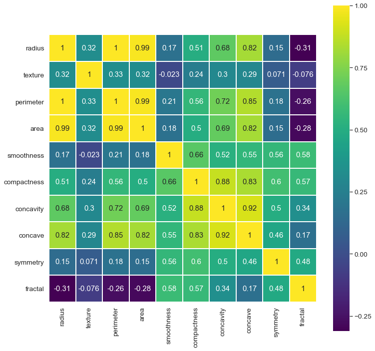

```python
corr=df.corr()
import matplotlib.pyplot as plt
plt.figure(figsize=(12,12))
sb.set(font_scale=1.25)
sb.heatmap(corr, square=True, annot=True, fmt='.2g', cmap='viridis', linewidths=1)
```

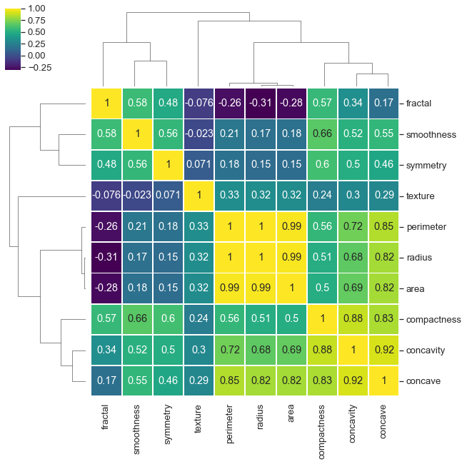

```python
plt.figure(figsize=(15,15))
sb.set(font_scale=1.2)
sb.clustermap(corr, square=True, annot=True, fmt='.2g', cmap='viridis', linewidths=1)
```

```python
X=df.iloc[:,1:12]
X.head()
```

|  | radius | texture | perimeter | area | smoothness | compactness | concavity | concave | symmetry | fractal |
| --- | --- | --- | --- | --- | --- | --- | --- | --- | --- | --- |
| 0 | 17.99 | 10.38 | 122.80 | 1001.0 | 0.11840 | 0.27760 | 0.3001 | 0.14710 | 0.2419 | 0.07871 |
| 1 | 20.57 | 17.77 | 132.90 | 1326.0 | 0.08474 | 0.07864 | 0.0869 | 0.07017 | 0.1812 | 0.05667 |
| 2 | 19.69 | 21.25 | 130.00 | 1203.0 | 0.10960 | 0.15990 | 0.1974 | 0.12790 | 0.2069 | 0.05999 |
| 3 | 11.42 | 20.38 | 77.58 | 386.1 | 0.14250 | 0.28390 | 0.2414 | 0.10520 | 0.2597 | 0.09744 |
| 4 | 20.29 | 14.34 | 135.10 | 1297.0 | 0.10030 | 0.13280 | 0.1980 | 0.10430 | 0.1809 | 0.05883 |

```python
Y=df['Diagnosis']
Y.head()
```

```
0    M
1    M
2    M
3    M
4    M
Name: Diagnosis, dtype: object
```

```python
from sklearn.preprocessing import LabelEncoder
```

```python
lbe=LabelEncoder().fit(Y)
```

```python
Y=lbe.transform(Y)
```

```python
Y
```

```
array([1, 1, 1, 1, 1, 1, 1, 1, 1, 1, 1, 1, 1, 1, 1, 1, 1, 1, 1, 0, 0, 0,
       1, 1, 1, 1, 1, 1, 1, 1, 1, 1, 1, 1, 1, 1, 1, 0, 1, 1, 1, 1, 1, 1,
       1, 1, 0, 1, 0, 0, 0, 0, 0, 1, 1, 0, 1, 1, 0, 0, 0, 0, 1, 0, 1, 1,
       0, 0, 0, 0, 1, 0, 1, 1, 0, 1, 0, 1, 1, 0, 0, 0, 1, 1, 0, 1, 1, 1,
       0, 0, 0, 1, 0, 0, 1, 1, 0, 0, 0, 1, 1, 0, 0, 0, 0, 1, 0, 0, 1, 0,
       0, 0, 0, 0, 0, 0, 0, 1, 1, 1, 0, 1, 1, 0, 0, 0, 1, 1, 0, 1, 0, 1,
       1, 0, 1, 1, 0, 0, 1, 0, 0, 1, 0, 0, 0, 0, 1, 0, 0, 0, 0, 0, 0, 0,
       0, 0, 1, 0, 0, 0, 0, 1, 1, 0, 1, 0, 0, 1, 1, 0, 0, 1, 1, 0, 0, 0,
       0, 1, 0, 0, 1, 1, 1, 0, 1, 0, 1, 0, 0, 0, 1, 0, 0, 1, 1, 0, 1, 1,
       1, 1, 0, 1, 1, 1, 0, 1, 0, 1, 0, 0, 1, 0, 1, 1, 1, 1, 0, 0, 1, 1,
       0, 0, 0, 1, 0, 0, 0, 0, 0, 1, 1, 0, 0, 1, 0, 0, 1, 1, 0, 1, 0, 0,
       0, 0, 1, 0, 0, 0, 0, 0, 1, 0, 1, 1, 1, 1, 1, 1, 1, 1, 1, 1, 1, 1,
       1, 1, 0, 0, 0, 0, 0, 0, 1, 0, 1, 0, 0, 1, 0, 0, 1, 0, 1, 1, 0, 0,
       0, 0, 0, 0, 0, 0, 0, 0, 0, 0, 0, 1, 0, 0, 1, 0, 1, 0, 0, 0, 0, 0,
       0, 0, 0, 0, 0, 0, 0, 0, 0, 1, 0, 0, 0, 1, 0, 1, 0, 0, 0, 0, 1, 1,
       1, 0, 0, 0, 0, 1, 0, 1, 0, 1, 0, 0, 0, 1, 0, 0, 0, 0, 0, 0, 0, 1,
       1, 1, 0, 0, 0, 0, 0, 0, 0, 0, 0, 0, 0, 1, 1, 0, 1, 1, 1, 0, 1, 1,
       0, 0, 0, 0, 0, 1, 0, 0, 0, 0, 0, 1, 0, 0, 0, 1, 0, 0, 1, 1, 0, 0,
       0, 0, 0, 0, 1, 0, 0, 0, 0, 0, 0, 0, 1, 0, 0, 0, 0, 0, 1, 0, 0, 1,
       0, 0, 0, 0, 0, 0, 0, 0, 0, 0, 0, 0, 1, 0, 1, 1, 0, 1, 0, 0, 0, 0,
       0, 1, 0, 0, 1, 0, 1, 0, 0, 1, 0, 1, 0, 0, 0, 0, 0, 0, 0, 0, 1, 1,
       0, 0, 0, 0, 0, 0, 1, 0, 0, 0, 0, 0, 0, 0, 0, 0, 0, 1, 0, 0, 0, 0,
       0, 0, 0, 1, 0, 1, 0, 0, 1, 0, 0, 0, 0, 0, 1, 1, 0, 1, 0, 1, 0, 0,
       0, 0, 0, 1, 0, 0, 1, 0, 1, 0, 1, 1, 0, 0, 0, 1, 0, 0, 0, 0, 0, 0,
       0, 0, 0, 0, 0, 1, 0, 1, 1, 0, 0, 0, 0, 0, 0, 0, 0, 0, 0, 0, 0, 0,
       0, 0, 0, 0, 0, 0, 0, 0, 0, 0, 0, 0, 1, 1, 1, 1, 1, 1, 0])
```

Nilai 1 pada Data Diagnosis mewakili **Malignat** sedang nilai 0 mewakili **Benign**,

```python
kmeans=KMeans(n_clusters=2)
```

```python
kmeans.fit(X)
```

```
KMeans(algorithm='auto', copy_x=True, init='k-means++', max_iter=300,
       n_clusters=2, n_init=10, n_jobs=None, precompute_distances='auto',
       random_state=None, tol=0.0001, verbose=0)
```

```python
y_kmeans=kmeans.predict(X)
```

```python
centers=kmeans.cluster_centers_
```

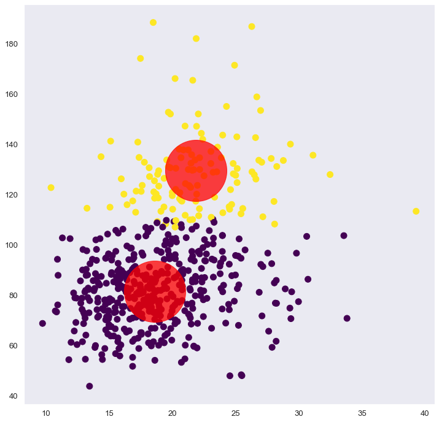

```python
plt.figure(figsize=(12,12))
plt.scatter(X.iloc[:,1], X.iloc[:,2], c=y_kmeans, s=100, cmap='viridis')
plt.scatter(centers[:,1], centers[:,2], c='red', s=10000, alpha=0.75)

plt.grid(False)
```

## *Confusion Matrix*

Dalam bidang *machine learning* dan khususnya masalah klasifikasi statistik , Confusion Matrix , yang juga dikenal sebagai matriks kesalahan, [4] adalah tata letak tabel spesifik yang memungkinkan visualisasi kinerja suatu algoritma, biasanya *supervised learning* (dalam belajar tanpa pengawasan biasanya disebut matriks *contingency*). Setiap baris matriks mewakili nilai dalam kelas yang diprediksi sementara setiap kolom mewakili nilai dalam kelas sebenarnya (atau sebaliknya). [2] Nama ini berasal dari fakta bahwa membuatnya mudah untuk melihat apakah sistem membingungkan dua kelas (yaitu umumnya salah memberi label satu sama lain).

Ini adalah jenis khusus dari tabel kontingensi , dengan dua dimensi ("aktual" dan "diperkirakan"), dan set "kelas" yang identik di kedua dimensi (setiap kombinasi dimensi dan kelas adalah variabel dalam tabel kontingensi).

```python
from sklearn.metrics import confusion_matrix
```

```python
confusion_matrix(Y, y_kmeans)
```

```
array([[355,   2],
       [ 90, 122]], dtype=int64)
```

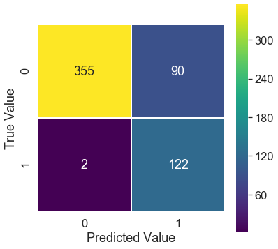

```python
conf=confusion_matrix(Y, y_kmeans)
plt.figure(figsize=(6,6))
sb.set(font_scale=1.5)
sb.heatmap(conf.T, square=True, annot=True, fmt='.3g', cmap='viridis', linewidths=1)
plt.xlabel('Predicted Value')
plt.ylabel('True Value')
```

```python
from sklearn.metrics import accuracy_score
accuracy_score(Y, y_kmeans)
```

```
0.8383128295254832
```

### Adjusted Mutual Information

Metrik ini merupakan pengukuran simetris: perbandingan label_true dengan label_pred akan menghasilkan nilai skor yang sama. Ini bisa bermanfaat untuk mengukur kesesuaian dua label independen pada dataset yang sama ketika label yang sebenarnya tidak diketahui.

```python
from sklearn.metrics import adjusted_mutual_info_score
print(adjusted_mutual_info_score(Y, y_kmeans, average_method='arithmetic'))
print("Skore mendekati nilai 1 untuk klaster yang identik.")
```

```
0.41876947005731385
Skore mendekati nilai 1 untuk klaster yang identik.
```

### Rand index adjusted

```python
from sklearn.metrics import adjusted_rand_score
print(adjusted_rand_score(Y, y_kmeans))
print("Skore mendekati nilai 1 untuk klaster yang identik.")
```

```
0.4457449374936547
Skore mendekati nilai 1 untuk klaster yang identik.
```

### Calinski and Harabaz score

```python
from sklearn.metrics import calinski_harabaz_score
print(calinski_harabaz_score(X, y_kmeans))
print("Skore menunjukkan rasio dispersi dalam klaster terhadap dispersi antar klaster.")
```

```
1317.9848900002903
Skore menunjukkan rasio dispersi dalam klaster terhadap dispersi antar klaster.
```

[output not shown]

### Davies-Bouldin score

```python
from sklearn.metrics import davies_bouldin_score
print(davies_bouldin_score(X, y_kmeans))
print("Skore menunjukkan rasio jarak dalam klaster terhadap jarak antar klaster.")
```

```
0.46601783424826154
Skore menunjukkan rasio jarak dalam klaster terhadap jarak antar klaster.
```

### Completeness Score

```python
from sklearn.metrics import completeness_score
print(completeness_score(Y, y_kmeans))
print("*Completeness* menunjukkan apakah semua titik data untuk kelompok yang sama merupakan anggota klaster yang sama.")
```

```
0.47408260425808346
*Completeness* menunjukkan apakah semua titik data untuk kelompok yang sama merupakan anggota klaster yang sama.
```

### Contingency Matrix

```python
from sklearn.metrics.cluster import contingency_matrix
print(contingency_matrix(Y, y_kmeans,eps=None, sparse=False))
```

```
[[355   2]
 [ 90 122]]
```

Matriks antara nilai sebenarnya dengan nilai prediksi. Matrix ini serupa dengan *Confusion Matrix*

### Fowlkes Mallows Score

```python
from sklearn.metrics import fowlkes_mallows_score
print(fowlkes_mallows_score(Y, y_kmeans))
```

```
0.7762511790232877
```

Skore bernilai antara 0 sampai dengan 1. Semakin tinggi nilai semakin bagus tingkat kesamaan antara nilai sebenarnya dengan nilai prediksi.

### Homogeneity and Completeness

```python
from sklearn.metrics import homogeneity_completeness_v_measure
homogeneity_completeness_v_measure(Y, y_kmeans)
```

```
(0.37640684390460405, 0.47408260425808346, 0.4196358631006221)
```

Mempunyai nilai antara 0.0 sampai dengan 1.0. Nilai yang baik adalah nilai yang mendekati 1.0

### Homogeneity Score

```python
from sklearn.metrics import homogeneity_score
homogeneity_score(Y, y_kmeans)
```

```
0.37640684390460405
```

Skor antara 0.0 sampai dengan 1.0. Skor 1.0 menunjukkan labelisasi homogen

### Mutual Info Score

```python
from sklearn.metrics import mutual_info_score
mutual_info_score(Y, y_kmeans, contingency=None)
```

```
0.2485475929791861
```

Nilai yang didasarkan pada perhitungan *contingency matrix*

### Normalized Mutual Info Score

```python
from sklearn.metrics import normalized_mutual_info_score
normalized_mutual_info_score(Y, y_kmeans, average_method='arithmetic')
```

```
0.4196358631006222
```

Skor antara 0.0 sampai dengan 1.0. Skor 1.0 menunjukkan labelisasi total

### Silhouette Score

```python
from sklearn.metrics import silhouette_score
print(silhouette_score(X, y_kmeans))
```

```
0.6991355163262034
```

Nilai paling bagus adalah 1 dan nilai paling jelek adalah -1. Nilai mendekati 0 menunjukkan klaster yang tumpang tindih. Nilai negatif menunjukkan bahwa sampel dikelompokkan ke dalam klaster yang salah

### Silhouette Samples

```python
from sklearn.metrics import silhouette_samples
print(silhouette_samples(X, y_kmeans))
```

[output not shown]

[output cut: 40 more lines]

[output not shown]

Nilai paling bagus adalah 1 dan nilai paling jelek adalah -1. Nilai mendekati 0 menunjukkan klaster yang tumpang tindih.

### v_measure Score

```python
from sklearn.metrics import v_measure_score
print(v_measure_score(Y, y_kmeans))
```

```
0.4196358631006221
```

Skor antara 0.0 sampai dengan 1.0. Skor 1.0 menunjukkan labelisasi total

```python
from sklearn.cluster import k_means
k_means(X, n_clusters=3, sample_weight=None, init='k-means++', precompute_distances='auto', n_init=10, max_iter=300, verbose=False, tol=0.0001, random_state=None, copy_x=True, n_jobs=None, algorithm='auto', return_n_iter=True)
```

```
(array([[1.18186401e+01, 1.82645428e+01, 7.60350147e+01, 4.35482596e+02,
         9.46703835e-02, 8.41574926e-02, 5.03849578e-02, 2.69867375e-02,
         1.77174336e-01, 6.40443068e-02],
        [2.06604819e+01, 2.21549398e+01, 1.36998795e+02, 1.33857831e+03,
         1.01569518e-01, 1.54592771e-01, 1.96433976e-01, 1.11134096e-01,
         1.91921687e-01, 6.01077108e-02],
        [1.57625170e+01, 2.00358503e+01, 1.03289864e+02, 7.74838776e+02,
         9.73161224e-02, 1.22513129e-01, 1.16614218e-01, 6.43697959e-02,
         1.84282313e-01, 6.14413605e-02]]),
 array([2, 1, 1, 0, 1, 0, 2, 0, 0, 0, 2, 2, 1, 2, 0, 2, 2, 2, 1, 0, 0, 0,
        2, 1, 2, 2, 2, 1, 2, 2, 1, 0, 2, 1, 2, 2, 2, 0, 2, 0, 0, 0, 1, 0,
        0, 1, 0, 0, 0, 0, 0, 0, 0, 2, 2, 0, 1, 2, 0, 0, 0, 0, 2, 0, 0, 2,
        0, 0, 0, 0, 1, 0, 2, 0, 0, 2, 0, 2, 1, 0, 0, 0, 1, 1, 0, 1, 2, 1,
        0, 2, 2, 2, 0, 0, 2, 1, 0, 0, 0, 2, 0, 0, 0, 0, 0, 0, 0, 0, 1, 0,
        0, 0, 2, 0, 0, 0, 0, 2, 2, 2, 0, 1, 1, 2, 0, 0, 0, 1, 2, 1, 0, 2,
        2, 2, 1, 0, 0, 0, 2, 0, 0, 2, 0, 0, 0, 0, 0, 2, 2, 0, 0, 0, 0, 0,
        0, 0, 2, 2, 0, 0, 0, 1, 1, 0, 1, 2, 0, 2, 2, 2, 0, 0, 2, 0, 0, 0,
        0, 2, 0, 0, 1, 1, 2, 0, 2, 0, 2, 0, 0, 0, 2, 0, 0, 0, 2, 0, 0, 2,
        1, 2, 0, 2, 1, 0, 0, 2, 0, 2, 0, 2, 1, 0, 1, 2, 2, 0, 0, 0, 1, 1,
        0, 0, 0, 2, 0, 2, 0, 2, 0, 0, 2, 0, 0, 1, 0, 0, 1, 1, 2, 2, 0, 0,
        0, 0, 1, 0, 0, 0, 0, 0, 1, 0, 1, 2, 1, 0, 1, 2, 2, 2, 1, 2, 2, 2,
        2, 1, 0, 0, 0, 0, 2, 0, 1, 0, 2, 0, 0, 1, 0, 0, 1, 0, 1, 2, 0, 0,
        0, 0, 0, 0, 2, 2, 0, 0, 0, 0, 0, 0, 2, 0, 1, 0, 1, 0, 0, 0, 0, 0,
        0, 0, 0, 2, 0, 0, 0, 0, 0, 2, 0, 0, 0, 1, 0, 1, 0, 0, 2, 0, 2, 2,
        2, 0, 0, 0, 0, 2, 0, 1, 0, 1, 2, 0, 0, 1, 0, 0, 0, 2, 0, 0, 0, 2,
        1, 2, 0, 0, 0, 0, 0, 0, 0, 0, 0, 2, 0, 1, 1, 0, 1, 1, 2, 2, 1, 1,
        0, 2, 0, 0, 0, 0, 0, 0, 0, 0, 0, 2, 0, 0, 0, 1, 0, 0, 2, 1, 0, 2,
        0, 0, 0, 0, 2, 0, 0, 0, 0, 0, 2, 0, 2, 0, 0, 0, 0, 2, 2, 0, 0, 2,
        0, 0, 0, 2, 0, 0, 0, 0, 0, 0, 0, 0, 2, 0, 1, 1, 2, 0, 0, 2, 0, 2,
        0, 2, 0, 0, 2, 0, 2, 2, 2, 1, 0, 1, 0, 2, 0, 0, 0, 0, 0, 0, 2, 1,
        2, 0, 0, 0, 0, 0, 2, 0, 0, 0, 2, 0, 0, 0, 2, 0, 0, 2, 0, 0, 0, 0,
        2, 0, 2, 1, 0, 2, 0, 2, 2, 0, 0, 2, 0, 0, 1, 1, 2, 0, 0, 1, 0, 0,
        0, 0, 2, 2, 0, 2, 0, 2, 2, 0, 2, 1, 0, 0, 0, 1, 0, 0, 0, 0, 0, 0,
        0, 0, 0, 0, 0, 1, 0, 1, 2, 0, 0, 0, 0, 2, 2, 0, 0, 0, 0, 0, 0, 0,
        0, 0, 0, 0, 0, 0, 0, 0, 2, 0, 0, 0, 2, 1, 1, 1, 2, 1, 0]),
 13185019.078159723,
 13)
```

KEMBALI KE DAFTAR ISI

# **Belajar Principal Component Analysis (PCA) Menggunakan Python**

Suprapto van Plaosan

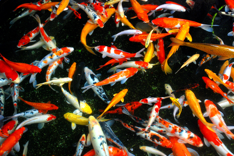

http://www.gardenfish.co.uk/types-of-pond-fish.htm

Principal component analysis ( PCA ) adalah prosedur statistik yang menggunakan transformasi ortogonal untuk mengubah seperangkat pengamatan dari variabel yang mungkin berkorelasi (entitas yang masing-masing mengambil berbagai nilai numerik) menjadi seperangkat nilai variabel tidak linear yang disebut komponen utama . Transformasi ini didefinisikan sedemikian rupa sehingga komponen utama pertama memiliki varians sebesar mungkin (yaitu, menyumbang sebanyak variabilitas dalam data mungkin), dan setiap komponen berikutnya pada gilirannya memiliki varians tertinggi yang mungkin di bawah kendala bahwa itu ortogonalke komponen sebelumnya. Vektor yang dihasilkan (masing-masing merupakan kombinasi linear dari variabel dan berisi n pengamatan) adalah himpunan basis ortogonal yang tidak berkorelasi . PCA sensitif terhadap skala relatif dari variabel asli.

PCA ditemukan pada tahun 1901 oleh Karl Pearson , [1] sebagai analog dari teorema sumbu utama dalam mekanika; kemudian dikembangkan secara independen dan dinamai oleh Harold Hotelling pada 1930-an. [2] Bergantung pada bidang aplikasi, ia juga dinamai diskrit Karhunen-Loève (KLT) dalam pemrosesan sinyal , transformasi Hotelling dalam kontrol kualitas multivariat, dekomposisi ortogonal yang tepat (POD) dalam teknik mesin, dekomposisi nilai singular (SVD) ) dari X (Golub dan Van Loan, 1983), dekomposisi nilai eigen (EVD) dari XT X dalam aljabar linier, analisis faktor (untuk diskusi tentang perbedaan antara PCA dan analisis faktor, lihat Bab 7 dari Analisis Komponen Utama Jolliffe ), [3] Eckart-Young theorem (Harman, 1960), atau fungsi ortogonal empiris (EOF ) dalam ilmu meteorologi, dekomposisi fungsi eigen empiris (Sirovich, 1987), analisis komponen empiris (Lorenz, 1956), mode quasiharmonic (Brooks et al., 1988), dekomposisi spektral dalam kebisingan dan getaran, dan analisis modal empiris dalam dinamika struktural.

PCA sebagian besar digunakan sebagai alat dalam analisis data eksplorasi dan untuk membuat model prediksi . Ini sering digunakan untuk memvisualisasikan jarak genetik dan keterkaitan antar populasi. PCA dapat dilakukan dengan dekomposisi nilai eigen dari matriks kovarians data (atau korelasi ) atau dekomposisi nilai singular dari matriks data , biasanya setelah langkah normalisasi data awal. Normalisasi setiap atribut terdiri dari pemusatan rata - rata - mengurangkan setiap nilai data dari rata-rata variabel yang diukur sehingga rata-rata empirisnya (rata-rata) adalah nol - dan, mungkin, menormalkan varian masing-masing variabel agar sama dengan 1; LihatSkor-Z . [4] Hasil PCA biasanya dibahas dalam hal skor komponen , kadang-kadang disebut skor faktor (nilai variabel yang ditransformasikan sesuai dengan titik data tertentu), dan pembebanan (bobot di mana setiap variabel asli standar harus dikalikan untuk mendapatkan skor komponen). [5]Jika skor komponen distandarisasi untuk varians unit, memuat harus berisi varians data di dalamnya (dan itu adalah besarnya nilai eigen). Jika skor komponen tidak distandarisasi (karena itu mengandung varians data) maka pemuatan harus berskala-unit, ("dinormalisasi") dan bobot ini disebut vektor eigen; mereka adalah cosinus dari rotasi orthogonal variabel menjadi komponen utama atau belakang.

PCA adalah analisis multivariat berbasis vektor eigen yang paling sederhana . Seringkali, operasinya dapat dianggap sebagai mengungkapkan struktur internal data dengan cara yang paling menjelaskan perbedaan dalam data. Jika dataset multivariat divisualisasikan sebagai seperangkat koordinat dalam ruang data dimensi tinggi (1 sumbu per variabel), PCA dapat menyediakan gambar dimensi yang lebih rendah kepada pengguna, proyeksi objek ini jika dilihat dari sudut pandang paling informatif [ rujukan? ] . Ini dilakukan dengan hanya menggunakan beberapa komponen utama pertama sehingga dimensi data yang diubah berkurang.

PCA terkait erat dengan analisis faktor . Analisis faktor biasanya memasukkan lebih banyak asumsi spesifik domain tentang struktur yang mendasarinya dan memecahkan vektor eigen dari matriks yang sedikit berbeda.

PCA juga terkait dengan analisis korelasi kanonik (CCA) . CCA mendefinisikan sistem koordinat yang secara optimal menggambarkan cross-covariance antara dua dataset sementara PCA mendefinisikan sistem koordinat orthogonal baru yang secara optimal menggambarkan varians dalam satu dataset. [6] [7]

```python
from sklearn.decomposition import PCA
```

```python
import pandas as pd
df=pd.read_csv('iris.csv')
```

Data iris flower akan digunakan untuk pengolahan data menggunakan PCA

The Iris Data bunga ditetapkan atau Fisher Iris kumpulan data adalah multivariat kumpulan data diperkenalkan oleh British statistik dan biologi Ronald Fisher pada tahun 1936 makalahnya Penggunaan beberapa pengukuran di masalah taksonomi sebagai contoh analisis diskriminan linier . [1] Kadang-kadang disebut set data Iris Anderson karena Edgar Anderson mengumpulkan data untuk menghitung variasi morfologis bunga Iris dari tiga spesies terkait.[2] Dua dari tiga spesies dikumpulkan di Semenanjung Gaspé "semuanya berasal dari padang rumput yang sama, dan dipetik pada hari yang sama dan diukur pada saat yang sama oleh orang yang sama dengan peralatan yang sama". [3]

Set data terdiri dari 50 sampel dari masing-masing dari tiga spesies Iris ( Iris setosa , Iris virginica dan Iris versicolor ). Empat fitur diukur dari masing-masing sampel: panjang dan lebar sepal dan kelopak , dalam sentimeter. Berdasarkan kombinasi keempat fitur ini, Fisher mengembangkan model diskriminan linier untuk membedakan spesies dari satu sama lain.

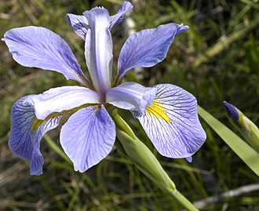

Iris setosa (juga dikenal sebagai iris bulu-runcing ), adalah spesies dalam genus Iris , juga dalam subgenus Limniris dan dalam seri Iris Tripetalae . Ini adalah tanaman rhizomatosa abadi dari berbagai wilayah di laut Arktik, termasuk Alaska , Maine , Kanada (termasuk British Columbia , Newfoundland , Quebec dan Yukon ), Rusia (termasuk Siberia ), Asia timur laut, Cina , Koreadan ke selatan ke Jepang. Tanaman ini memiliki batang bercabang tinggi, daun hijau tengah dan ungu, ungu-biru, ungu-biru, biru, hingga bunga lavender. Ada juga tanaman dengan bunga merah muda dan putih.

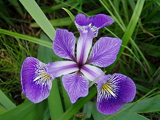

Iris versicolor juga dikenal sebagai bendera biru , blueflag harlequin , bendera biru yang lebih besar , bendera biru utara , [1] dan bendera racun , ditambah variasi lain dari nama-nama ini, [2] [3] dan di Inggris dan Irlandia sebagai iris ungu . [4]

Ini adalah spesies Iris asli Amerika Utara, di Amerika Serikat bagian Timur dan Kanada Timur . Hal ini biasa terjadi di padang rumput, rawa-rawa, dan sepanjang streambanks dan pantai. Versitet julukan spesifik berarti "berbagai warna". [5]

Ini adalah salah satu dari tiga spesies Iris dalam data bunga Iris yang ditetapkan oleh Ronald Fisher dalam makalahnya tahun 1936 "Penggunaan berbagai pengukuran dalam masalah taksonomi" sebagai contoh analisis diskriminan linier .

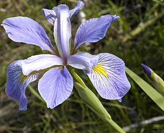

Iris virginica , dengan nama umum Virginia iris , adalah abadi spesies dari tanaman berbunga , asli Amerika Utara bagian timur.

Hal ini biasa terjadi di sepanjang dataran pantai dari Florida ke Georgia di Amerika Serikat Tenggara . [2]

Ini adalah salah satu dari tiga spesies Iris dalam data bunga Iris yang ditetapkan oleh Ronald Fisher dalam makalahnya tahun 1936 "Penggunaan berbagai pengukuran dalam masalah taksonomi" sebagai contoh analisis diskriminan linier .

```python
df=df.drop('Unnamed: 0', axis=1)
df.head()
```

|  | sepal_length | sepal_width | petal_length | petal_width | class |
| --- | --- | --- | --- | --- | --- |
| 0 | 5.1 | 3.5 | 1.4 | 0.2 | Iris-setosa |
| 1 | 4.9 | 3.0 | 1.4 | 0.2 | Iris-setosa |
| 2 | 4.7 | 3.2 | 1.3 | 0.2 | Iris-setosa |
| 3 | 4.6 | 3.1 | 1.5 | 0.2 | Iris-setosa |
| 4 | 5.0 | 3.6 | 1.4 | 0.2 | Iris-setosa |

```python
X=df.iloc[:,0:4]
X.head()
```

|  | sepal_length | sepal_width | petal_length | petal_width |
| --- | --- | --- | --- | --- |
| 0 | 5.1 | 3.5 | 1.4 | 0.2 |
| 1 | 4.9 | 3.0 | 1.4 | 0.2 |
| 2 | 4.7 | 3.2 | 1.3 | 0.2 |
| 3 | 4.6 | 3.1 | 1.5 | 0.2 |
| 4 | 5.0 | 3.6 | 1.4 | 0.2 |

```python
Y=df['class']
Y.head()
```

```
0    Iris-setosa
1    Iris-setosa
2    Iris-setosa
3    Iris-setosa
4    Iris-setosa
Name: class, dtype: object
```

```python
from sklearn.preprocessing import LabelEncoder
lbe=LabelEncoder()
Y=lbe.fit_transform(Y)
Y
```

```
array([0, 0, 0, 0, 0, 0, 0, 0, 0, 0, 0, 0, 0, 0, 0, 0, 0, 0, 0, 0, 0, 0,
       0, 0, 0, 0, 0, 0, 0, 0, 0, 0, 0, 0, 0, 0, 0, 0, 0, 0, 0, 0, 0, 0,
       0, 0, 0, 0, 0, 0, 1, 1, 1, 1, 1, 1, 1, 1, 1, 1, 1, 1, 1, 1, 1, 1,
       1, 1, 1, 1, 1, 1, 1, 1, 1, 1, 1, 1, 1, 1, 1, 1, 1, 1, 1, 1, 1, 1,
       1, 1, 1, 1, 1, 1, 1, 1, 1, 1, 1, 1, 2, 2, 2, 2, 2, 2, 2, 2, 2, 2,
       2, 2, 2, 2, 2, 2, 2, 2, 2, 2, 2, 2, 2, 2, 2, 2, 2, 2, 2, 2, 2, 2,
       2, 2, 2, 2, 2, 2, 2, 2, 2, 2, 2, 2, 2, 2, 2, 2, 2, 2])
```

```python
pca=PCA(n_components=3)
```

```python
x_pca=pca.fit_transform(X)
```

```python
import numpy as np
covmat=np.cov(x_pca.T)
```

```python
print(covmat)
```

```
[[ 4.22484077e+00 -1.19218580e-16  7.15311479e-17]
 [-1.19218580e-16  2.42243572e-01 -4.91776642e-17]
 [ 7.15311479e-17 -4.91776642e-17  7.85239081e-02]]
```

```python
eigenval, eigenvec=np.linalg.eig(covmat)
```

```python
print(eigenval)
```

```
[4.22484077 0.24224357 0.07852391]
```

```python
print(eigenvec)
```

```
[[ 1.00000000e+00 -2.99348827e-17 -1.72517322e-17]
 [ 0.00000000e+00 -1.00000000e+00  2.77555756e-16]
 [ 0.00000000e+00  3.33066907e-16  1.00000000e+00]]
```

```python
eig_pairs=[(np.abs(eigenval[i]),eigenvec[:,i]) for i in range(len(eigenval))]
tot=sum(eigenval)
```

```python
var_exp=[(i/tot)*100 for i in sorted(eigenval, reverse=True)]
var_exp
```

```
[92.94335406356555, 5.329178371934544, 1.7274675644999145]
```

```python
cum_var_exp = np.cumsum(var_exp)
print(cum_var_exp)
```

```
[ 92.94335406  98.27253244 100.        ]
```

```python
import numpy as np
import matplotlib.pyplot as plt

plt.figure(figsize=(9,6))
plt.bar(range(3),var_exp,alpha=0.5, align='center',label='Individual Explained Variance')
plt.step(range(3),cum_var_exp, 'r-', alpha=0.5, where='mid',label='Cumulative Explained Variance')
plt.ylabel('Explained Variance Ratio')
plt.xlabel('Principal Component')
plt.legend(loc='best')
```

[output not shown]

Komponen utama pertama, atau PC1, 'menjelaskan varian paling banyak' dalam dataset asli - ini juga berarti bahwa fitur yang berkorelasi dengan PC1 berkontribusi terhadap sejumlah besar variasi dalam data.

Saat Anda beralih dari PC1 ke PC final, jumlah varians yang dijelaskan berkurang, sedangkan varians yang dijelaskan kumulatif mendekati 100%. Jika Anda ingin mengurangi jumlah dimensi untuk analisis, Anda dapat memilih jumlah PC tertentu berdasarkan pada seberapa banyak variasi dijelaskan (mis. 95%). Anda juga dapat memahami seberapa banyak perbedaan dijelaskan hanya dalam dua atau tiga dimensi yang mudah divisualisasikan.

Saat menganalisis data dengan banyak variabel, saya ingin memahami berapa banyak dan fitur mana yang berguna. Saya bekerja di genomik, di mana Anda dapat dengan mudah memiliki ribuan fitur per instance dan memahami berapa banyak fitur yang saya butuhkan membuatnya lebih mudah untuk melatih dan menafsirkan model pada data itu. Dalam genomik, fitur itu murah dan instansinya berharga. Untuk alasan ini, saya sering menggunakan PCA sebagai panduan untuk memilih fitur mana yang menjadi fokus.

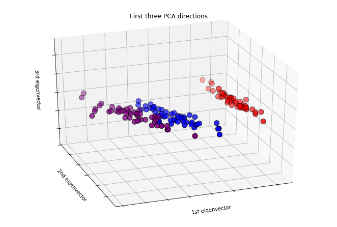

```python
from mpl_toolkits.mplot3d import Axes3D

fig=plt.figure(1,figsize=(9,6))
ax=Axes3D(fig,elev=-150,azim=110)
colormap=np.array(['red','blue','purple'])
ax.scatter(x_pca[:, 0], x_pca[:, 1],edgecolor='k', s=100,c=colormap[Y])
ax.set_title("First three PCA directions")
ax.set_xlabel("1st eigenvector")
ax.w_xaxis.set_ticklabels([])
ax.set_ylabel("2nd eigenvector")
ax.w_yaxis.set_ticklabels([])
ax.set_zlabel("3rd eigenvector")
ax.w_zaxis.set_ticklabels([])
plt.show()
```

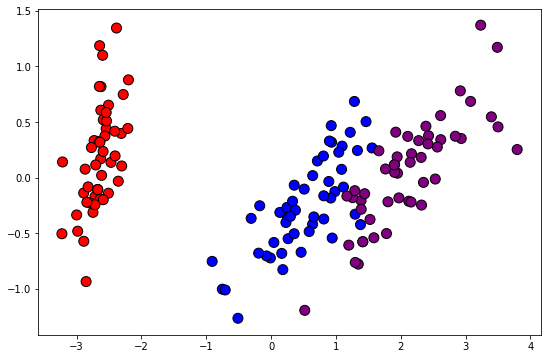

```python
plt.figure(figsize=(9,6))
plt.scatter(x_pca[:, 0], x_pca[:, 1],edgecolor='k', s=100,c=colormap[Y])
```

Kembali ke Daftar Isi

# **Affinity Propagation Clustering**

dari Wikipedia, ensiklopedia gratis

Dalam statistik dan penggalian data , Affinity Propagation (AP) adalah algoritma pengelompokan berdasarkan konsep "message passing" antara titik data. [1] Tidak seperti algoritma pengelompokan seperti k-means atau k-medoids, propagasi afinitas tidak memerlukan jumlah cluster yang harus ditentukan atau diperkirakan sebelum menjalankan algoritma. Mirip dengan k -medoid, propagasi afinitas menemukan "contoh" anggota kumpulan input yang mewakili cluster. [1]

Algoritma

Misalnya xi sampai dengan xn merupakan satu set titik data, tanpa asumsi tentang struktur internal mereka, dan membiarkan s menjadi fungsi yang mengkuantifikasi kesamaan antara dua titik, sehingga s ( xi , xj )> s ( xi , xk ) bila xi lebih mirip dengan xj daripada dengan xk. Maka, jarak kuadrat negatif dari dua titik data untuk titik xi dan xk.

$${\displaystyle s(i,k)=-\left\|x_{i}-x_{k}\right\|^{2}} {\displaystyle s(i,k)=-\left\|x_{i}-x_{k}\right\|^{2}}$$

Aplikasi Penemu propagasi afinitas menunjukkan bahwa AP lebih baik daripada k-means untuk aplikasi komputer *vision* dan komputasi biologi, misalnya mengelompokkan gambar wajah manusia dan mengidentifikasi transkrip yang diatur[1]. Sebuah studi yang membandingkan propagasi afinitas dan pengelompokan Markov pada partisi grafik interaksi protein menemukan bahwa pengelompokan Markov bekerja lebih baik untuk masalah itu. [3] Varian semi-diawasi telah diusulkan untuk aplikasi teks *mining* [4].

```python
from sklearn.cluster import AffinityPropagation
```

```python
import pandas as pd
```

```python
from sklearn.datasets import load_breast_cancer
```

Wisconsin Breast Cancer Diagnostic Datasets

Dataset yang digunakan adalah Wisconsin Breast Cancer Diagnostic. Diagnosis dan deteksi dini kanker payudara dengan mendiagnosis massa payudara dari Aspirasi Jarum Halus (FNA) telah dibuat yang memungkinkan diagnosis FNA payudara bahkan oleh pengguna yang tidak terlatih. Sistem ini digunakan di Rumah Sakit University of Wisconsin. Antarmuka grafis dikembangkan untuk menghitung fitur wilayah kecil dari FNA didigitalkan, menghasilkan 640 × 400, 8-bit-per-pixel gambar grayscale. Program analisis gambar, program Xcyt digunakan untuk fitting kurva untuk menentukan batas-batas inti. Sebagian dari gambar yang diproses ditunjukkan pada Gambar 1. Sepuluh fitur dihitung untuk masing-masing inti: luas, jari-jari, keliling, simetri, jumlah dan ukuran cekung, dimensi fraktal (batas), kekompakan, kehalusan dan tekstur. Data diagnosis berisi simbol B **dan** M yang mewakili Benign/Sehat dan Malignant/Sakit.

Sebagian besar jenis kanker payudara mudah didiagnosis dengan analisis mikroskopis sampel — atau biopsi — pada area payudara yang terkena. Juga, ada beberapa jenis kanker payudara yang memerlukan ujian laboratorium khusus.

Dua metode skrining yang paling umum digunakan, pemeriksaan fisik payudara oleh penyedia layanan kesehatan dan mamografi, dapat menawarkan kemungkinan perkiraan bahwa benjolan adalah kanker, dan juga dapat mendeteksi beberapa lesi lain, seperti kista sederhana . [89] Ketika pemeriksaan ini tidak dapat disimpulkan, penyedia layanan kesehatan dapat mengeluarkan sampel cairan dalam benjolan untuk analisis mikroskopis (prosedur yang dikenal sebagai aspirasi jarum halus)., atau aspirasi jarum halus dan sitologi — FNAC) untuk membantu menegakkan diagnosis. Aspirasi jarum dapat dilakukan di kantor atau klinik penyedia layanan kesehatan. Anestesi lokal dapat digunakan untuk mematikan jaringan payudara untuk mencegah rasa sakit selama prosedur, tetapi mungkin tidak diperlukan jika benjolan tidak berada di bawah kulit. Temuan cairan bening membuat benjolan tersebut sangat tidak mungkin menjadi kanker, tetapi cairan berdarah dapat dikirim untuk diperiksa di bawah mikroskop untuk sel-sel kanker. Bersama-sama, pemeriksaan fisik payudara, mamografi, dan FNAC dapat digunakan untuk mendiagnosis kanker payudara dengan tingkat akurasi yang baik.

Pilihan lain untuk biopsi termasuk biopsi inti atau biopsi payudara berbantuan vakum , [90] yang merupakan prosedur di mana sebagian benjolan payudara diangkat; atau biopsi eksisi , di mana seluruh benjolan dihilangkan. Sangat sering hasil pemeriksaan fisik oleh penyedia layanan kesehatan, mamografi, dan tes tambahan yang dapat dilakukan dalam keadaan khusus (seperti pencitraan dengan USG atau MRI ) cukup untuk menjamin biopsi eksisi sebagai diagnostik definitif dan metode perawatan primer.

```python
wdbc=load_breast_cancer()
```

```python
wdbc.data
```

```
array([[1.799e+01, 1.038e+01, 1.228e+02, ..., 2.654e-01, 4.601e-01,
        1.189e-01],
       [2.057e+01, 1.777e+01, 1.329e+02, ..., 1.860e-01, 2.750e-01,
        8.902e-02],
       [1.969e+01, 2.125e+01, 1.300e+02, ..., 2.430e-01, 3.613e-01,
        8.758e-02],
       ...,
       [1.660e+01, 2.808e+01, 1.083e+02, ..., 1.418e-01, 2.218e-01,
        7.820e-02],
       [2.060e+01, 2.933e+01, 1.401e+02, ..., 2.650e-01, 4.087e-01,
        1.240e-01],
       [7.760e+00, 2.454e+01, 4.792e+01, ..., 0.000e+00, 2.871e-01,
        7.039e-02]])
```

```python
wdbc.data.shape
```

```
(569, 30)
```

```python
wdbc.target
```

```
array([0, 0, 0, 0, 0, 0, 0, 0, 0, 0, 0, 0, 0, 0, 0, 0, 0, 0, 0, 1, 1, 1,
       0, 0, 0, 0, 0, 0, 0, 0, 0, 0, 0, 0, 0, 0, 0, 1, 0, 0, 0, 0, 0, 0,
       0, 0, 1, 0, 1, 1, 1, 1, 1, 0, 0, 1, 0, 0, 1, 1, 1, 1, 0, 1, 0, 0,
       1, 1, 1, 1, 0, 1, 0, 0, 1, 0, 1, 0, 0, 1, 1, 1, 0, 0, 1, 0, 0, 0,
       1, 1, 1, 0, 1, 1, 0, 0, 1, 1, 1, 0, 0, 1, 1, 1, 1, 0, 1, 1, 0, 1,
       1, 1, 1, 1, 1, 1, 1, 0, 0, 0, 1, 0, 0, 1, 1, 1, 0, 0, 1, 0, 1, 0,
       0, 1, 0, 0, 1, 1, 0, 1, 1, 0, 1, 1, 1, 1, 0, 1, 1, 1, 1, 1, 1, 1,
       1, 1, 0, 1, 1, 1, 1, 0, 0, 1, 0, 1, 1, 0, 0, 1, 1, 0, 0, 1, 1, 1,
       1, 0, 1, 1, 0, 0, 0, 1, 0, 1, 0, 1, 1, 1, 0, 1, 1, 0, 0, 1, 0, 0,
       0, 0, 1, 0, 0, 0, 1, 0, 1, 0, 1, 1, 0, 1, 0, 0, 0, 0, 1, 1, 0, 0,
       1, 1, 1, 0, 1, 1, 1, 1, 1, 0, 0, 1, 1, 0, 1, 1, 0, 0, 1, 0, 1, 1,
       1, 1, 0, 1, 1, 1, 1, 1, 0, 1, 0, 0, 0, 0, 0, 0, 0, 0, 0, 0, 0, 0,
       0, 0, 1, 1, 1, 1, 1, 1, 0, 1, 0, 1, 1, 0, 1, 1, 0, 1, 0, 0, 1, 1,
       1, 1, 1, 1, 1, 1, 1, 1, 1, 1, 1, 0, 1, 1, 0, 1, 0, 1, 1, 1, 1, 1,
       1, 1, 1, 1, 1, 1, 1, 1, 1, 0, 1, 1, 1, 0, 1, 0, 1, 1, 1, 1, 0, 0,
       0, 1, 1, 1, 1, 0, 1, 0, 1, 0, 1, 1, 1, 0, 1, 1, 1, 1, 1, 1, 1, 0,
       0, 0, 1, 1, 1, 1, 1, 1, 1, 1, 1, 1, 1, 0, 0, 1, 0, 0, 0, 1, 0, 0,
       1, 1, 1, 1, 1, 0, 1, 1, 1, 1, 1, 0, 1, 1, 1, 0, 1, 1, 0, 0, 1, 1,
       1, 1, 1, 1, 0, 1, 1, 1, 1, 1, 1, 1, 0, 1, 1, 1, 1, 1, 0, 1, 1, 0,
       1, 1, 1, 1, 1, 1, 1, 1, 1, 1, 1, 1, 0, 1, 0, 0, 1, 0, 1, 1, 1, 1,
       1, 0, 1, 1, 0, 1, 0, 1, 1, 0, 1, 0, 1, 1, 1, 1, 1, 1, 1, 1, 0, 0,
       1, 1, 1, 1, 1, 1, 0, 1, 1, 1, 1, 1, 1, 1, 1, 1, 1, 0, 1, 1, 1, 1,
       1, 1, 1, 0, 1, 0, 1, 1, 0, 1, 1, 1, 1, 1, 0, 0, 1, 0, 1, 0, 1, 1,
       1, 1, 1, 0, 1, 1, 0, 1, 0, 1, 0, 0, 1, 1, 1, 0, 1, 1, 1, 1, 1, 1,
       1, 1, 1, 1, 1, 0, 1, 0, 0, 1, 1, 1, 1, 1, 1, 1, 1, 1, 1, 1, 1, 1,
       1, 1, 1, 1, 1, 1, 1, 1, 1, 1, 1, 1, 0, 0, 0, 0, 0, 0, 1])
```

```python
wdbc.target.shape
```

```
(569,)
```

```python
X=wdbc.data
```

```python
Y=wdbc.target
```

```python
apc=AffinityPropagation(damping=0.99, max_iter=1000, convergence_iter=5)
```

```python
apc.fit(X)
```

```
AffinityPropagation(affinity='euclidean', convergence_iter=5, copy=True,
                    damping=0.99, max_iter=1000, preference=None,
                    verbose=False)
```

```python
y_apc=apc.predict(X)
```

```python
import matplotlib.pyplot as plt
```

```python
centers=apc.cluster_centers_
```

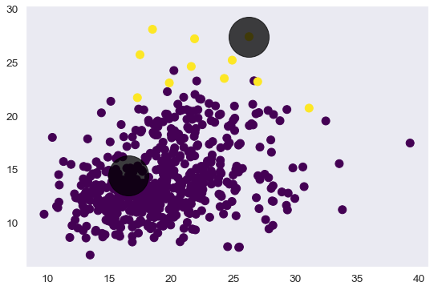

```python
plt.figure(figsize=(9,6))
plt.scatter(X[:,1], X[:,0], c=y_apc, s=100, cmap='viridis')
plt.scatter(centers[:,1], centers[:,0], c='black', s=2500, alpha=0.75)

plt.grid(False)
```

```python
from sklearn.metrics import confusion_matrix
```

```python
confusion_matrix(Y, y_apc)
```

```
array([[201,  11],
       [357,   0]], dtype=int64)
```

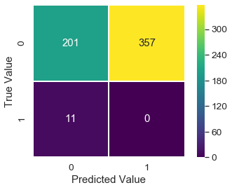

```python
import seaborn as sb
conf=confusion_matrix(Y, y_apc)
sb.set(font_scale=1.25)
sb.heatmap(conf.T, square=True, annot=True, fmt='.3g', cmap='viridis', linewidths=1)
plt.xlabel('Predicted Value')
plt.ylabel('True Value')
```

```python
from sklearn.metrics import accuracy_score
accuracy_score(Y, y_apc)
```

```
0.3532513181019332
```

### Adjusted Mutual Information

Metrik ini merupakan pengukuran simetris: perbandingan label_true dengan label_pred akan menghasilkan nilai skor yang sama. Ini bisa bermanfaat untuk mengukur kesesuaian dua label independen pada dataset yang sama ketika label yang sebenarnya tidak diketahui.

```python
from sklearn.metrics import adjusted_mutual_info_score
print(adjusted_mutual_info_score(Y, y_apc, average_method='arithmetic'))
print("Skore mendekati nilai 1 untuk klaster yang identik.")
```

```
0.049012400828395905
Skore mendekati nilai 1 untuk klaster yang identik.
```

### Rand index adjusted

```python
from sklearn.metrics import adjusted_rand_score
print(adjusted_rand_score(Y, y_apc))
print("Skore mendekati nilai 1 untuk klaster yang identik.")
```

```
0.02766435305873888
Skore mendekati nilai 1 untuk klaster yang identik.
```

### Calinski and Harabaz score

```python
from sklearn.metrics import calinski_harabaz_score
print(calinski_harabaz_score(X, y_apc))
print("Skore menunjukkan rasio dispersi dalam klaster terhadap dispersi antar klaster.")
```

```
218.59530450081903
Skore menunjukkan rasio dispersi dalam klaster terhadap dispersi antar klaster.
```

[output not shown]

### Davies-Bouldin score

```python
from sklearn.metrics import davies_bouldin_score
print(davies_bouldin_score(X, y_apc))
print("Skore menunjukkan rasio jarak dalam klaster terhadap jarak antar klaster.")
```

```
0.37432120765773436
Skore menunjukkan rasio jarak dalam klaster terhadap jarak antar klaster.
```

### Completeness Score

```python
from sklearn.metrics import completeness_score
print(completeness_score(Y, y_apc))
print("*Completeness* menunjukkan apakah semua titik data untuk kelompok yang sama merupakan anggota klaster yang sama.")
```

```
0.20338679005542998
*Completeness* menunjukkan apakah semua titik data untuk kelompok yang sama merupakan anggota klaster yang sama.
```

### Contingency Matrix

```python
from sklearn.metrics.cluster import contingency_matrix
print(contingency_matrix(Y, y_apc,eps=None, sparse=False))
```

```
[[201  11]
 [357   0]]
```

Matriks antara nilai sebenarnya dengan nilai prediksi. Matrix ini serupa dengan *Confusion Matrix*

### Fowlkes Mallows Score

```python
from sklearn.metrics import fowlkes_mallows_score
print(fowlkes_mallows_score(Y, y_apc))
```

```
0.7242644920784216
```

Skore bernilai antara 0 sampai dengan 1. Semakin tinggi nilai semakin bagus tingkat kesamaan antara nilai sebenarnya dengan nilai prediksi.

### Homogeneity and Completeness

```python
from sklearn.metrics import homogeneity_completeness_v_measure
homogeneity_completeness_v_measure(Y, y_apc)
```

```
(0.029393330723380785, 0.20338679005542998, 0.05136362301784874)
```

Mempunyai nilai antara 0.0 sampai dengan 1.0. Nilai yang baik adalah nilai yang mendekati 1.0

### Homogeneity Score

```python
from sklearn.metrics import homogeneity_score
homogeneity_score(Y, y_apc)
```

```
0.029393330723380785
```

Skor antara 0.0 sampai dengan 1.0. Skor 1.0 menunjukkan labelisasi homogen

### Mutual Info Score

```python
from sklearn.metrics import mutual_info_score
mutual_info_score(Y, y_apc, contingency=None)
```

```
0.019408896833950723
```

Nilai yang didasarkan pada perhitungan *contingency matrix*

### Normalized Mutual Info Score

```python
from sklearn.metrics import normalized_mutual_info_score
normalized_mutual_info_score(Y, y_apc, average_method='arithmetic')
```

```
0.05136362301784875
```

Skor antara 0.0 sampai dengan 1.0. Skor 1.0 menunjukkan labelisasi total

### Silhouette Score

```python
from sklearn.metrics import silhouette_score
print(silhouette_score(X, y_apc))
```

```
0.7204649384370724
```

Nilai paling bagus adalah 1 dan nilai paling jelek adalah -1. Nilai mendekati 0 menunjukkan klaster yang tumpang tindih. Nilai negatif menunjukkan bahwa sampel dikelompokkan ke dalam klaster yang salah

### Silhouette Samples

```python
from sklearn.metrics import silhouette_samples
print(silhouette_samples(X, y_apc))
```

[output not shown]

[output cut: 40 more lines]

[output not shown]

Nilai paling bagus adalah 1 dan nilai paling jelek adalah -1. Nilai mendekati 0 menunjukkan klaster yang tumpang tindih.

### v_measure Score

```python
from sklearn.metrics import v_measure_score
print(v_measure_score(Y, y_apc))
```

```
0.05136362301784874
```

Skor antara 0.0 sampai dengan 1.0. Skor 1.0 menunjukkan labelisasi total

Kembali ke Daftar Isi